# Introduction

Storms and other severe weather events can cause both public health and economic problems for communities and municipalities. Many severe events can result in fatalities, injuries, and property damage, and preventing such outcomes to the extent possible is a key concern.

This project involves exploring the U.S. National Oceanic and Atmospheric Administration’s (NOAA) storm database. This database tracks characteristics of major storms and weather events in the United States, including when and where they occur, as well as estimates of any fatalities, injuries, and property damage.

#### Data

The data for this assignment come in the form of a comma-separated-value file compressed via the bzip2 algorithm to reduce its size. The size of the Storm Data is **[47Mb]**

There is also some documentation of the database available. Here you will find how some of the variables are constructed/defined.

[National Weather Service Storm Data Documentation](https://d396qusza40orc.cloudfront.net/repdata%2Fpeer2_doc%2Fpd01016005curr.pdf)  
[National Climatic Data Center Storm Events FAQ](https://d396qusza40orc.cloudfront.net/repdata%2Fpeer2_doc%2FNCDC%20Storm%20Events-FAQ%20Page.pdf)

The events in the database start in the year 1950 and end in November 2011. In the earlier years of the database there are generally fewer events recorded, most likely due to a lack of good records. More recent years should be considered more complete.

#### Aim of the analysis

The basic goal of this exercise is to explore the NOAA Storm Database and answer some basic questions about severe weather events.

# 1 - Synopsis

In this report, we will analysis the data storm data provided by the Johns Hopkins University

My data analysis aims to address the following questions:

1. Across the United States, which types of events (as indicated in the **EVTYPE** variable) are most harmful with respect to population health?
2. Across the United States, which types of events have the greatest economic consequences?

# 2 - Data Processing

#### Data preperation

From a list of variables in storm.data, these are columns of interest:

#### Health variables:

**FATALITIES:** approx. number of deaths  
**INJURIES:** approx. number of injuries

#### Economic variables:

**PROPDMG:** approx. property damags  
**PROPDMGEXP:** the units for property damage value  
**CROPDMG:** approx. crop damages  
**CROPDMGEXP:** the units for crop damage value

Events - target variable:

**EVTYPE:** weather event (Tornados, Wind, Snow, Flood, etc..)

```r
# we load the data from computer
raw.data <- read.csv(bzfile("StormData.csv.bz2"))

# required packages for this analysis
library(plyr)
library(dplyr)
library(ggplot2)
library(reshape2)
```

#### We kept only relevant variables for this analysis

```r
# check out column names
names(raw.data)
```

```
##  [1] "STATE__"    "BGN_DATE"   "BGN_TIME"   "TIME_ZONE"  "COUNTY"
##  [6] "COUNTYNAME" "STATE"      "EVTYPE"     "BGN_RANGE"  "BGN_AZI"
## [11] "BGN_LOCATI" "END_DATE"   "END_TIME"   "COUNTY_END" "COUNTYENDN"
## [16] "END_RANGE"  "END_AZI"    "END_LOCATI" "LENGTH"     "WIDTH"
## [21] "F"          "MAG"        "FATALITIES" "INJURIES"   "PROPDMG"
## [26] "PROPDMGEXP" "CROPDMG"    "CROPDMGEXP" "WFO"        "STATEOFFIC"
## [31] "ZONENAMES"  "LATITUDE"   "LONGITUDE"  "LATITUDE_E" "LONGITUDE_"
## [36] "REMARKS"    "REFNUM"
```

```r
# subset EVTYPE and cost related variables
raw.data <- raw.data[c(8, 23:28)]


# Only cases with fatalities or injuries occurred.
raw.data <- subset(raw.data, EVTYPE != "?" &  INJURIES > 0 | FATALITIES > 0 | PROPDMG > 0 | CROPDMG > 0)
```

# 3 - Converting the exponent columns (PROPDMGEXP and CROPDMGEXP)

These variables represent economic dimension of the costs but their contents include mixed values, such as numbers and characters. Thus, we need to standardize and convert to the numberic values.

```r
# first, we will check the properties
table(raw.data$PROPDMGEXP)
```

```
##
##             -      +      0      2      3      4      5      6      7      B
##  11585      1      5    210      1      1      4     18      3      3     40
##      h      H      K      m      M
##      1      6 231428      7  11320
```

```r
table(raw.data$CROPDMGEXP)
```

```
##
##             ?      0      B      k      K      m      M
## 152664      6     17      7     21  99932      1   1985
```

```r
# some variables have lower case values
# we are now converting lower cases to uppercases in these variables
raw.data <-  data.frame(lapply(raw.data, function(v) {
        if (is.character(v)) return(toupper(v))
        else return(v)
        }))
```

According to the previous tables, the CROPDMGEXP only contains a subset of these values. Most of the numerical exponents are missing. The factor is only calculated for the exponents provided in that variable.

```r
#  for PROPDNGEXP
raw.data2 <- raw.data
raw.data2$PROPDMGEXP <- mapvalues(raw.data2$PROPDMGEXP,
        from = c("K","M","", "B", "m", "+", "0","5", "6", "?", "4", "2", "3", "h", "7","H", "-","1", "8"),
        to = c(10^3,10^6,10^0,10^9,10^6,10^0,10^0,10^5,10^6,10^0,10^4,10^2,10^3,10^2,10^7,10^2,10^0,10^1,10^8))

raw.data2$PROPDMGEXP <- as.numeric(as.character(raw.data2$PROPDMGEXP))
# total PROPDMGEXP
raw.data2$PROPDMGTOTAL <- (raw.data2$PROPDMG * raw.data2$PROPDMGEXP)/1000000000

# for CROPDMGEXP
raw.data2$CROPDMGEXP <- mapvalues(raw.data2$CROPDMGEXP,
                                  from = c("",   "M",  "K",   "m",  "B",  "?",    "0",     "k",   "2"),
                                  to =   c(10^0, 10^6, 10^3,  10^6, 10^9,  10^0,   10^0,   10^3,  10^2))
raw.data2$CROPDMGEXP <- as.numeric(as.character(raw.data2$CROPDMGEXP))

# total CROPDMGEXP
raw.data2$CROPDMGTOTAL <- (raw.data2$CROPDMG * raw.data2$CROPDMGEXP)/1000000000
```

# 4 Results

#### Calculating Total Fatalities and Injuries

Table of public health problems by event type

```r
# We sum the fatalities and injuries to calculate the total effects of events on public health
mergedFI <- raw.data2 %>%
        group_by(EVTYPE)%>%
        summarise(total.fatalities=sum(FATALITIES), total.injuries= sum(INJURIES), total.sum= total.fatalities + total.injuries) %>%
        arrange(desc(total.sum))

mergedFI10 <- mergedFI[1:10,]

# check the list
head(mergedFI10, 5)
```

```
## # A tibble: 5 × 4
##   EVTYPE         total.fatalities total.injuries total.sum
##   <chr>                     <dbl>          <dbl>     <dbl>
## 1 TORNADO                    5633          91346     96979
## 2 EXCESSIVE HEAT             1903           6525      8428
## 3 TSTM WIND                   504           6957      7461
## 4 FLOOD                       470           6789      7259
## 5 LIGHTNING                   816           5230      6046
```

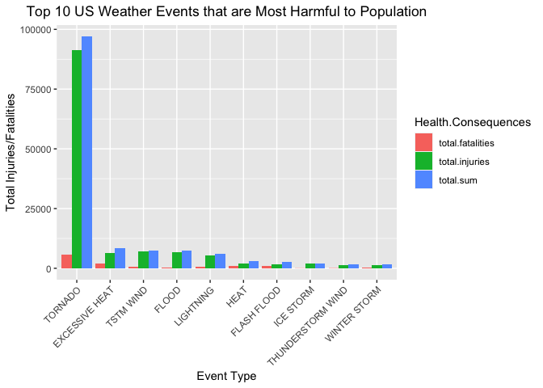

```r
############## plot
#gplot
# Melting data so that it is easier to put in bar graph format
Health_Consequences <- melt(mergedFI10, id.vars = "EVTYPE", variable.name = "Health.Consequences")

ggplot(Health_Consequences, aes(x = reorder(EVTYPE, -value), y = value)) +
        geom_bar(stat = "identity", aes(fill = Health.Consequences), position = "dodge") +
        ylab("Total Injuries/Fatalities") +
        xlab("Event Type") +
        theme(axis.text.x = element_text(angle=45, hjust=1)) +
        ggtitle("Top 10 US Weather Events that are Most Harmful to Population") +
        theme(plot.title = element_text(hjust = 0.5))
```

The barchart shows that *Tornados* are the most harmful weather events for people’s health.

#### Estimating the total of Property Cost and Crop Cost (Economic Impacts)

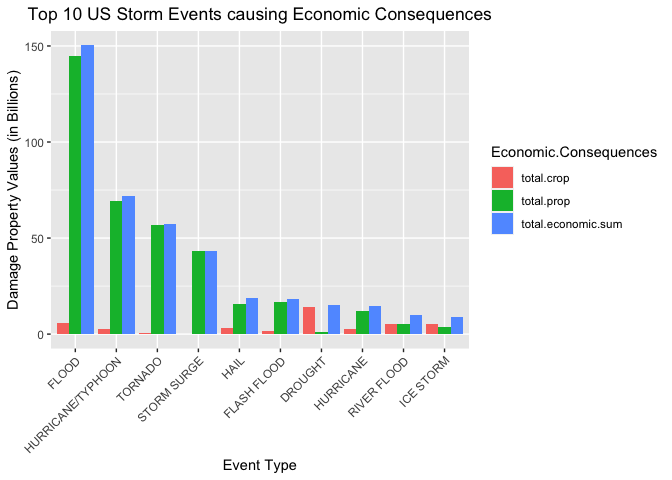

```r
############## Economic costs
# We sum the fatalities and injuries to calculate the total effects of events on public health
total.economic <- raw.data2 %>%
        group_by(EVTYPE)%>%
        summarise(total.crop= sum(CROPDMGTOTAL), total.prop= sum(PROPDMGTOTAL), total.economic.sum= total.crop + total.prop) %>%
        arrange(desc(total.economic.sum))


economic10 <- total.economic[1:10,]


# plot
# Melting data so that it is easier to put in bar graph format
Economic.Consequences <- melt(economic10, id.vars = "EVTYPE", variable.name = "Economic.Consequences")
ggplot(Economic.Consequences, aes(x = reorder(EVTYPE, -value), y = value)) +
        geom_bar(stat = "identity", aes(fill = Economic.Consequences), position = "dodge") +
        ylab("Damage Property Values (in Billions)") +
        xlab("Event Type") +
        theme(axis.text.x = element_text(angle=45, hjust=1)) +
        ggtitle("Top 10 US Storm Events causing Economic Consequences") +
        theme(plot.title = element_text(hjust = 0.5))
```

The bar chart shows that *Floods* cause the biggest economical damages.